# Seminar 04 Activities

### Seminar 04 - Adversarial search (games)

In this seminar, we will discuss: - adversarial search methods, such as **minmax**, **alpha-beta pruning**, **Monte-Carlo tree search**, - example games played using these methods, including Tic-Tac-Toe and Connect Four, and - other games such as Backgammon and Chess.

This seminar focuses on **adversarial search** problems, often known as **games**. They come from **competitive environments**, in which agents’ goals are in conflict. Notice that these environments differ from **multiagent environments**, in which each agent needs to consider the actions of other agents and this brings some **contingencies** into the agent’s problem solving process. *See References for additional readings on cooperative x competitive environments*.

In the AI scope, and a bit differently from the mathematical game theory, the most common games are of a rather specialized kind: *deterministic, turn-taking, two-player, zero-sum games of perfect information*. This means **deterministic, fully observable environments** in which two agents act alternately and in which the **utility values** at the end of the game are always equal and opposite. For example, if one player wins a game, the other player necessarily loses. It is this *opposition* between the agents’ utility functions that makes the situation *adversarial*.

### Learnng 1: How we can define and implement games?

We begin with a definition of the **optimal move** and an algorithm for find it. Different techniques can be used for choosing a good move when time is limited. **Pruning** allow us to ignore part of the search tree that make no difference to the final choice, and **heuristic evaluation functions** allow us to approximate the true utility of a state without doing a complete search. Some games have an **element of chance** (such as backgammon) or **elements of imperfect information** (a card game where no all cards are visible to each player, for example).

We start with games with two players, `MAX` and `MIN`, where `MAX` moves first and then the players take turns moving until the game is over. At the end of the game, points are awarded to the winner and penalties are given to the loser.

A game can be formally defined as a kind of *search problem* with the following elements:

- S<sub>0</sub>: the **initial state** of the game.
- `PLAYER(s)`: defines which player has the move in a state.
- `ACTIONS(s)`: returns the set of legal moves in a state.
- `RESULT(s,a)`: the **transition model**, which defines the result of a move.
- `TERMINAL_TEST(s)`: returns `TRUE` when the game is over and `FALSE` otherwise. States where the game has ended are called **terminal states**.
- `UTILITY(s,p)`: a **utility function** (or objective function) defines a final numerical value for a game that ends in a terminal state *s* for a player *p*.

In *chess*, the outcome is win, loss, or draw, with values +1, 0 and 1/2. Some games have a wider variety of possible outcomes: the payoffs in *backgammon*, for example, range from 0 to +192. A **zero-sum game** is defined as one where the total payoff to all players is the same for every instance of the game. Chess is zero-sum because every game has payoff of 0+1, 1+0, or 1/2+1/2.

The initial state (S<sub>0</sub>), `ACTIONS` and `RESULT` functions define the **game tree**: a tree where the nodes are game states and the edges are moves.

### Learning 2: Optimal decisions in games

In a normal search problem, the optimal solution would be a sequence of actions leading to a goal state – a terminal state that is a win. In adversarial search, `MIN` has something to say about it. `MAX` therefore must find a **contingent strategy**, which specifies `MAX`’s move in the initial state, then `MAX` moves in the states resulting from every possible response by `MIN`, and so on.

The figure below shows part of the game **Tic-Tac-Toe** (noughts and crosses). From the initial state, `MAX` has nine possible moves. Play alternates between `MAX` placing an *X* and `MIN` placing an *O* until we reach leaf nodes corresponding to terminal states such that one player has three in a row or all the squares are filled. The number on each leaf node indicates the utility value of the terminal state from the point of view of `MAX`: high values are assumed to be good for `MAX` and bad for `MIN`.

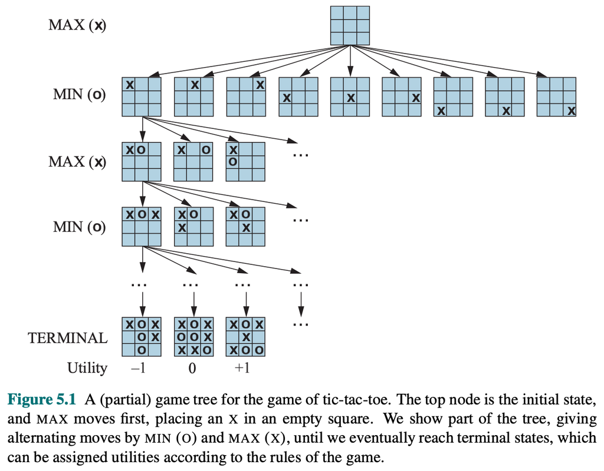

### Activity 1 - Fig52 (Lecture and textbook example)

The [w04_adversarial_search_games.ipynb](https://moodle.lse.ac.uk/pluginfile.php/2580983/mod_folder/content/0/w04_adversarial_search_games.ipynb?forcedownload=1) code shows how all these above concepts are implemented. The example code:

- uses a toy game example (`Fig52 Game`, from Figure 5.2 of the textbook) to explain how the **minmax** and **alpha-beta pruning** algorithms work.
- implements players with different behaviours (random, alpha-beta, query), and
- allows you (the “human”) to play against random and alpha-beta players.

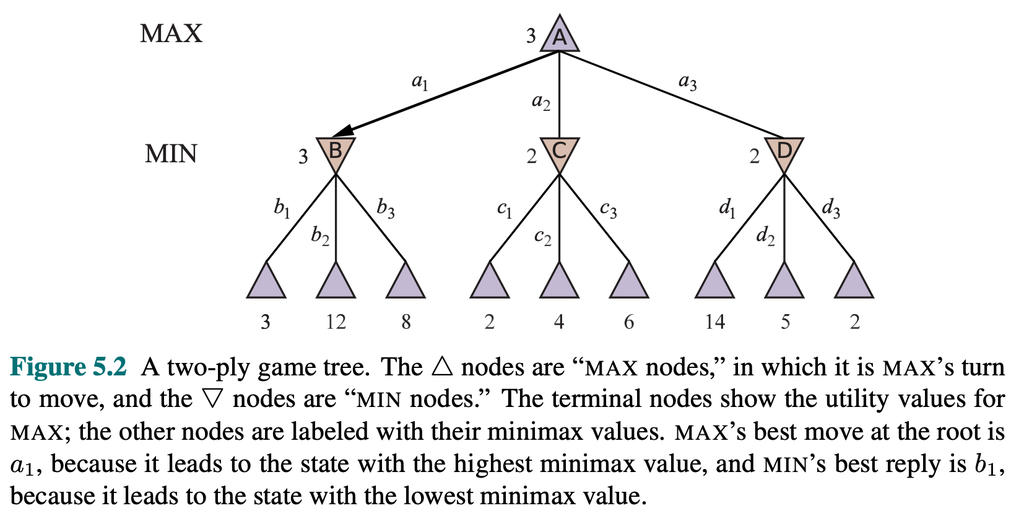

**How minmax and alpha-beta algorithms compare? (Click me)**

The **Minmax** algorithm generates the entire search space, whereas the **Alpha-beta pruning** algorithm allow us to prune large parts of it. However, alpha-beta still has to search all the way to terminal states for at least a portion of the search space. This depth is usually not practical, because moves must be made in a reasonable amount of time - typically a few minutes at most.

### Learning 3: Imperfect real-time decisions

Claude Shannon’s seminal paper [Programming a computer for playing Chess](https://vision.unipv.it/IA1/ProgrammingaComputerforPlayingChess.pdf) (1950) proposed that programs should **cut off the search earlier** and apply a **heuristic evaluation function** to states in the search, effectively turning nonterminal nodes into terminal leaves. The basic idea is to alter *minmax* or *alpha-beta* in two ways:

- replace the `utility` function by a heuristic evaluation function (`EVAL`), which estimates the position’s utility, and
- replace the terminal test by a **cutoff test**, that decides when to apply `EVAL`.

So, the heuristic minimax for state `s` and maximum depth `d` will be:

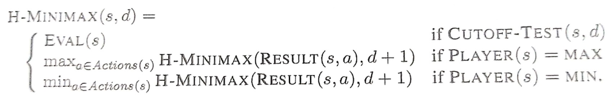

An **evaluation function** returns an *estimate* of the expected utility of the game from a given position. First, the evaluation function should order the *terminal* states in the same as the true utility function: states that are wins must evaluate better than draws, which in turn must be better than losses. Second, the computation must not take too long. And third, for non-terminal states, the evaluation function should be strongly correlated with the actual chances of winning.

Another step should modify the **Alpha-beta search** algorithm, so that it will call the heuristic `EVAL` function when it is appropriate to cut off the search. It’s basically a substitution of two lines of code that mention the `TERMINAL_TEST` with the `CUTOFF_TEST` and `EVAL` functions (see figure below, in red).

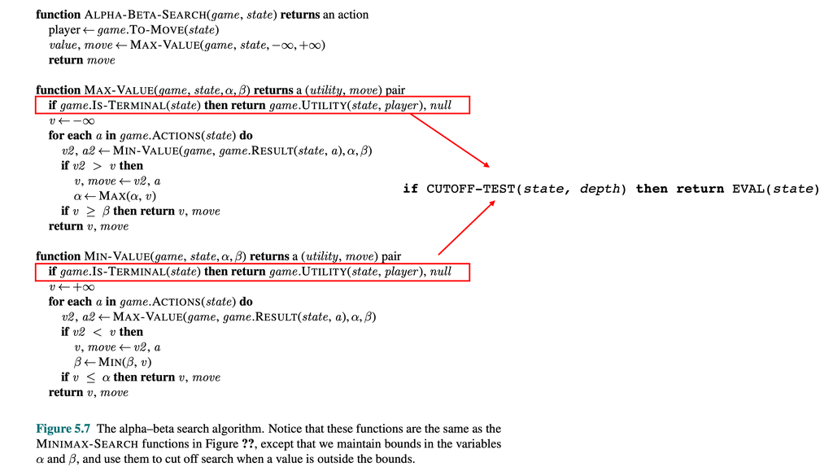

We should have some bookkeeping so that the current *depth* is incremented on each recursive call. The best approach for controlling the amount of search is to set a fixed depth limit so that `CUTOFF_TEST(state, depth)` returns *true* for all *depth* greater than some fixed depth *d*. Observe that a move will be selected within the allocated time. We can also use *iterative deepening*: when the time runs out, the program returns the move selected by the deepest completed search.

### Learning 4: Monte-Carlo tree search (MCTS)

**Monte Carlo tree search (MCTS)** is a heuristic search algorithm for many decision processes, such as being employed in software that plays board games. The focus of MCTS is on the analysis of the most promising moves, expanding the search tree based on random sampling of the search space.

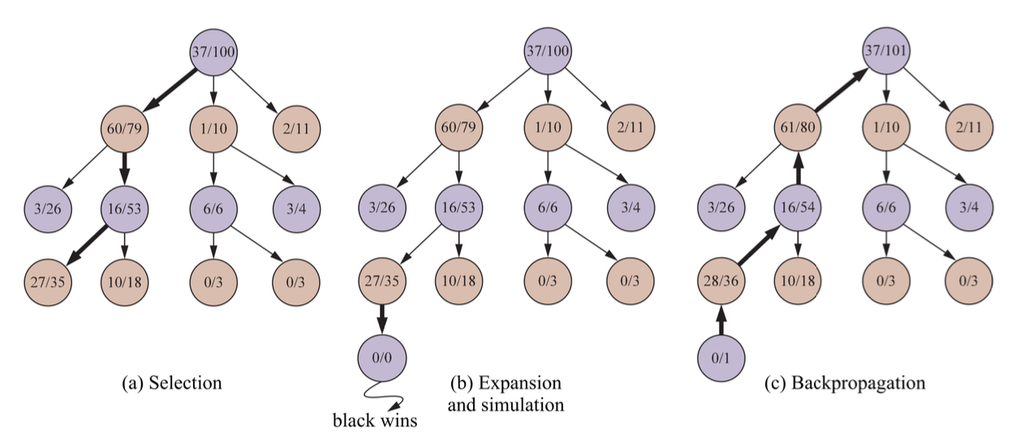

Each round of MCTS consists of four steps:

1. **(Selection)** Starting from the root node *R*, we select good child nodes, that can potentially lead to better overall outcome, until we reach a ‘leaf node’ *L*, which has not been fully expanded. A widely used selection policy is **UCT** (Upper Confidence bound 1 applied to Trees), which maintains a balance between **exploration and exploitation**.
2. **(Expansion)** Unless *L* ends the game (terminal state), we expand out its child nodes (based on legal moves) and select one **child node** *C* from them.
3. **(Simulation)** Run a simulated **playout** from *C* until a result is achieved. We can choose random moves in the playout.
4. **(Back-propagation)** Use the result of the playout to **update** information in the nodes on the path from *C* to *R*.

Rounds of search are repeated as long as the time allotted to a move remains; or, as in our implementation, we cap the number of rounds of search at *N*.

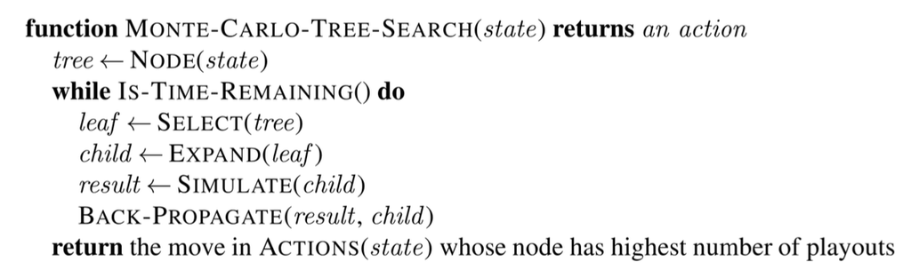

### Activity 2 - Tic-Tac-Toe and Connect Four games

In [w04_TTT_C4.ipynb](https://moodle.lse.ac.uk/pluginfile.php/2580983/mod_folder/content/0/w04_TTT_C4.ipynb?forcedownload=1), we look at two fun games in more detail: **Tic-Tac-Toe** (noughts and crosses) and **Connect Four**. For Tic-Tac-Toe, the example code includes:

- the representation of Tic-Tac-Toe game state using a namedtuple `GameState`,
- game playing with different players: random, alpha-beta, query (you, the “human”).

For Connect Four, the section of the notebook includes:

- using the class `TicTacToe` to define our game `C4`,
- implementing a player using **alpha-beta cutoff search** with a properly designed **evaluation function**,
- implementing a player using **Monte-Carlo tree search**,
- game playing between different players.

### Extra

Check out:

1. the Backgammon implementation code. Backgammon is a two-player stochastic game. We need to create chance nodes and then generalise the **minimax** value for deterministic games to an **expectiminimax** value. You can find the implemented functions and classes `def expect_minmax(state, game)`, `class StochasticGame(Game)`, `class Backgammon(StochasticGame)` in games4e.py;
2. [w04_Chess2.ipynb](https://moodle.lse.ac.uk/pluginfile.php/2580983/mod_folder/content/0/w04_Chess2.ipynb?forcedownload=1). This is an interactive Chess implementation. Can you spot some issues with this implementation? If you want to experiment more, have a look at the *References* section and the Python Chess library. You can explore **search vs lookup** approaches by introducing openings and endgame lookups into your Chess game.

### Activity 3 (homework)

#### Adversarial search

You can adapt the code from **Activity 1** to both examples below:

**Rock-paper-scissor game**

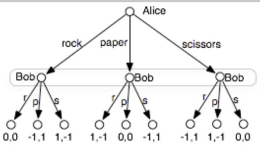

**Sharing game:** consider a sharing game where there are two agents, Andy and Barb, are there are two identical items to be divided between them. Andy first selects how they will be divided: Andy keeps both items, they share and each person gets one item, or he gives both items to Barb. Then Barb gets to either reject the allocation and they both get nothing, or accept the allocation and they both get the allocated amount.

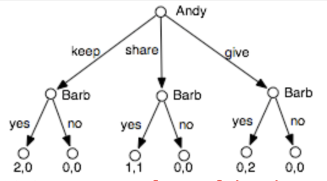

Is this a zero-sum game? What can happen in this game?

### Recommended references

- [Algorithms Explained – minimax and alpha-beta pruning](https://www.youtube.com/watch?v=l-hh51ncgDI) - Sebastian Lague.
- [Adversarial search](https://livebook.manning.com/book/classic-computer-science-problems-in-python/chapter-8/1) - from the book *Classic Computer Science problems in Python* (Manning).
- [Minimax with Alpha-Beta Pruning in Python](https://stackabuse.com/minimax-and-alpha-beta-pruning-in-python/)
- [Adversarial search in Java](https://notebook.community/aimacode/aima-java/notebooks/AdversarialSearch) - same examples from the reference book but in Java.

If you want to play a bit more with Chess, here are some specialised libraries and examples:

- [Python Chess](https://python-chess.readthedocs.io/en/latest/) library: it provides move generation and validation, opening books and endgame probing.
- [PyGames](https://www.pygame.org/wiki/GettingStarted) library.
- [Chess.com](https://www.youtube.com/watch?v=KYNbHGs-qG4) - Tutorial on the Chess.com API (Youtube).
- [Making Chess in Python](https://levelup.gitconnected.com/chess-python-ca4532c7f5a4)
- [Mastering Tic-Tac-Toe with Minimax Algorithm in Python](https://levelup.gitconnected.com/mastering-tic-tac-toe-with-minimax-algorithm-3394d65fa88f)
- PettingZoo - OpenAI Gym alternative implementing different environments (including board games)

If you want to experiment with **stochastic games**, specifically **backgammon**, have a look at these references:

- [Python backgammon](https://pypi.org/project/backgammon/) library.
- [Backgammon game using PyGame Library](https://www.youtube.com/watch?v=POTvpXrIlHo) - Youtube video with link to the project GitHub repo.

### Other references

- [An overview of cooperative and competitive multiagent learning](https://cs.gmu.edu/~sean/papers/LAMAS05Overview.pdf)
- [Multi-agent learning in both cooperative and competitive environments](https://paginas.fe.up.pt/~niadr/PUBLICATIONS/2013/EPIA2013_MALCoopCompEnv.pdf)
- [70 public GitHub repositories on Adversarial Search](https://github.com/topics/adversarial-search)
- [Python kriegspiel](https://pypi.org/project/kriegspiel/) library - for partially observable games.